# Work Package 3

## Stable water isotopes

Jason Lessels  
University of Aberdeen

[Download](https://github.com/johnDorian/work_package_3/zipball/gh-pages)

## Using isotopic and geochemical tracers to identify sources of runoff

**Aims and objectives**

1. Identify the main sources of water at the catchment scale.
2. Use this information to improve the understanding of the sources and fate of C through the catchment.

**How we will use the data**

- Precipitation samples: Identify the isotopic signature of precipitation inputs
- Soil water: Identify isotopic signature to monitor mixing of soil water and precipitation and the travel time from soil to the stream.
- Stream sampling (catchment outlet): Detect seasonal trends and allow for the calibration of estimated transit times.

## Data summary

| Data | Frequency | Objective |
| --- | --- | --- |
| Synoptic sampling | multiple times throughout 13 and 14 | Examine small scales controls |
| Extra synoptic sites | 2 visits (2014) | Incorporated into a network geospatial model |
| Stream discharge | (15 min - 2014) | Estimating loads and hydrological modeling |
| Soil water | multiple times at 2 depths (4 locations) during 2014 | Used in estimating transit times and identifying production and sources of DOC |
| Rainfall collection | throughout 2013 and 2014 | Used as input to transit time modeling |
| CDOM | (2 weeks during 2014) | Continuous estimates of DOC |

## Hydrological time series

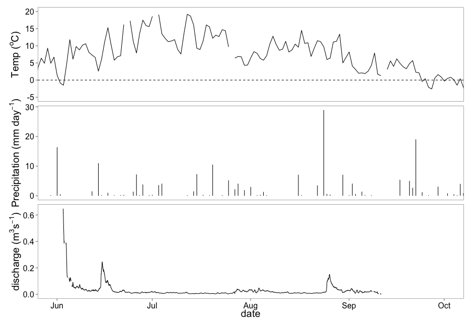

## Isotope overview

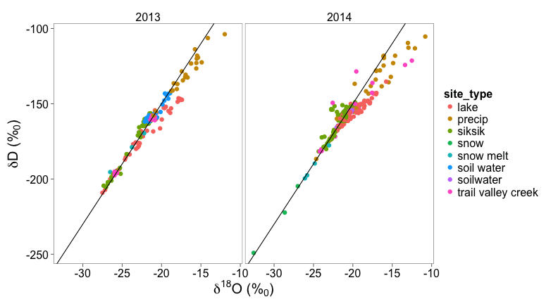

> A strong seasonal variation can be seen in the isotopes.

> The sources of water (rain, snow and soil water) have distinct signals

## Temporal isotope data

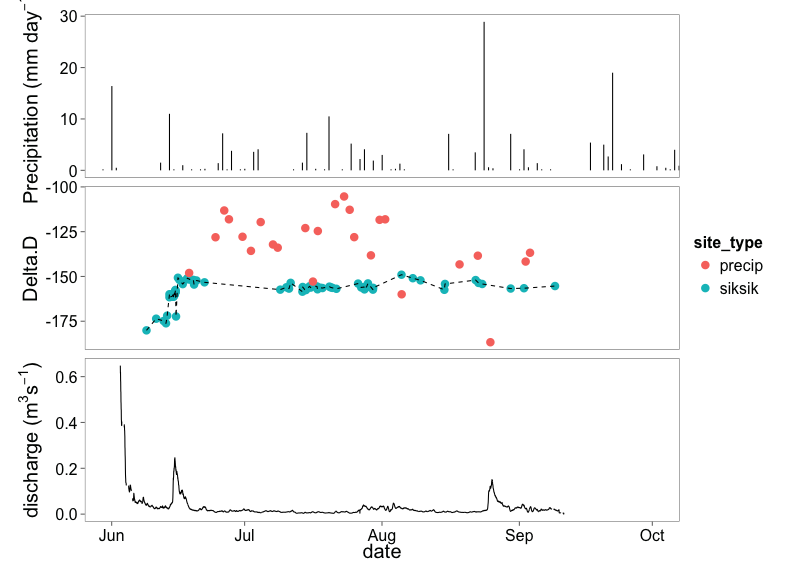

## Soil water Isotopes

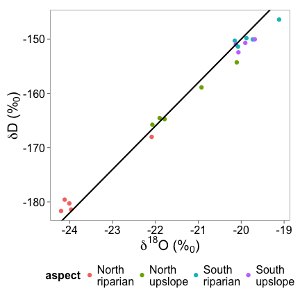

> There is a large variation between the two slopes

> This may be useful for identify and tracing carbon in the system

## CDOM data

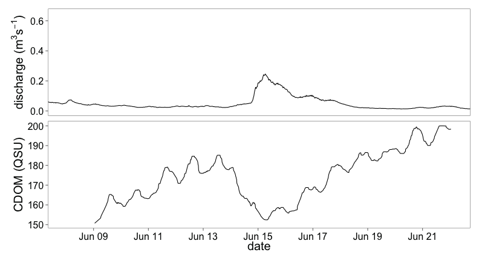

> CDOM is a good surrogate for DOC. There is large daily diurnal variation.

> The rainfall event had a dilution effect on DOC.

## Soil pH data

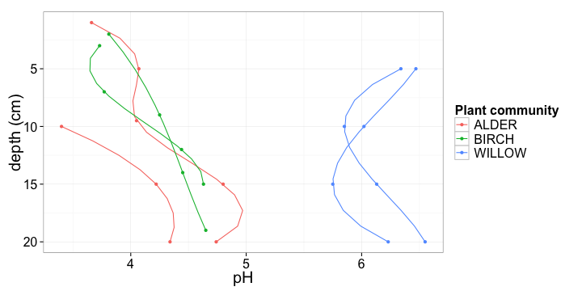

> Soil pH data collected at 14C profile sites.

> Willow sites differ greatly from the other sites.

> Additional samples were collected along transect 2.

## WP3 Summary

**Interesting findings so far**

> The isotope data looks promising to inform how C is transported through the catchment.

> Strongly controlled by active layer dynamics.

> Isotopes will be used to inform the hydrological model of the catchment.

**Paper Ideas**

> Linking soil dissolved carbon with stable isotopes to identify sources in Siksik

**Outreach**

Presentation at EGU 2013

# Work package 4

## Aims and objectives

1. Develop a parsimonious hydrological model for an Arctic catchment using hydrological tracers to improve model structure.

1. Use isotope data to estimate transit times in the catchment.
2. Improved hydrology and freeze/thaw routines for ECOSSE and improved DOC estimates for parsimonious hydrological model.

**Tasks completed**

- Developed a coupled hydrology-biogeochemistry model to simulate stream discharge and DOC for Granger catchment.

## Coupled model

**Hydrological component**

- Based on the conceptual HBV model.
- Includes an additional modules:
  - for the affect of slope facing aspects, and
  - freeze-thaw processes do to soil frost and permafrost conditions

**DOC component**

- Based on the DOC components of the ECOSSE model
- Simplified DOC production and loss functions using
  - a Q10 relationship for temperature, and
  - a soil moisture modifying term.

## Model outline

[figure not shown]

## Observed data from Granger catchment

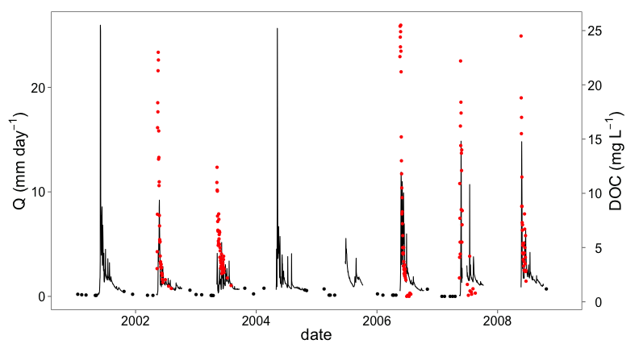

> Subarctic alpine catchment with permafrost on north facing slopes.

> Characterised with large spring melt stream discharge events early spring.

## Stream discharge simulations

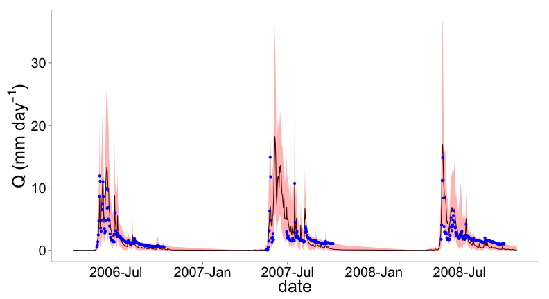

> Discharge simulations captured the spring melt timing and magnitude for most years.

> Simulated discharge is strongly correlated (\(r^2=0.67\)) with observed discharge.

## DOC simulations

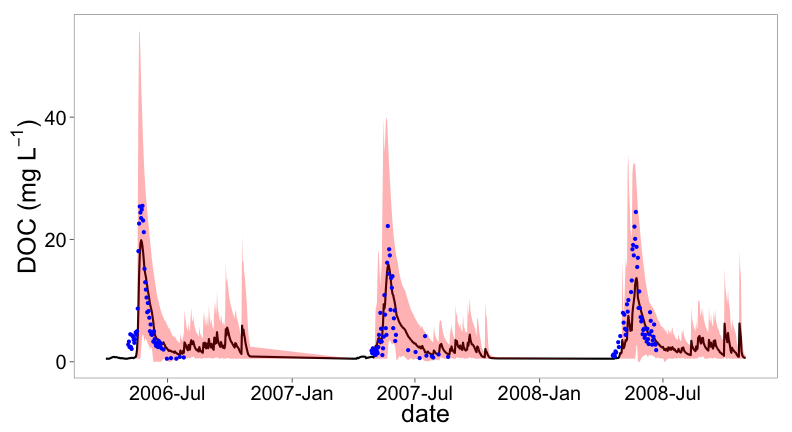

> The simulations also indicate that DOC concentrations increase later in the season.

## Coupled Simulations

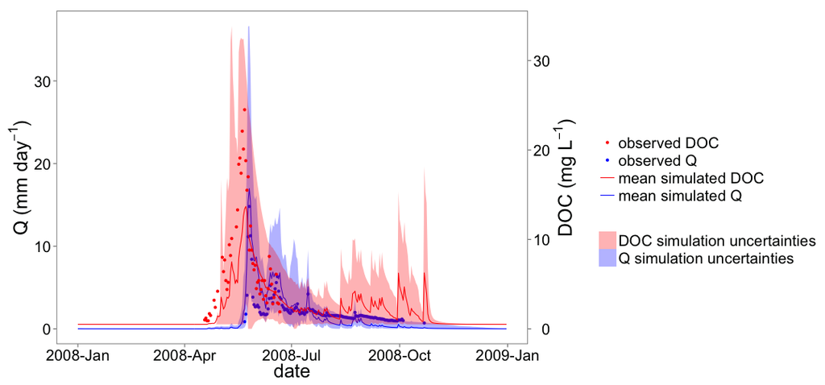

> Simulations closely resemble observed trends of both DOC and stream discharge.

## Simulated soil water DOC

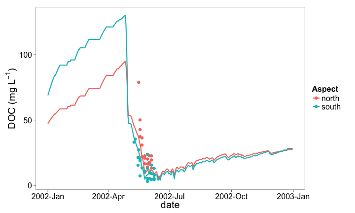

> Soil water DOC works well for the south facing slope, but is exported a little quickly on the north facing slope.

## Observed DOC v simulated DOC

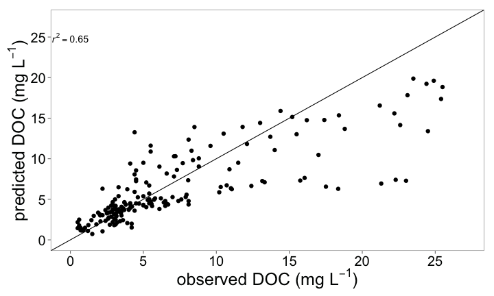

## Transit time modeling

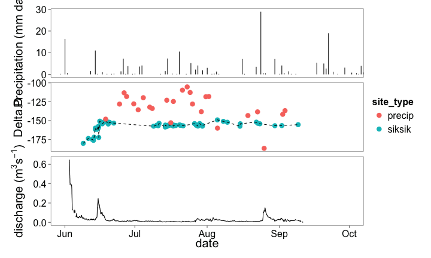

> Transit times are based on the *smoothing* of the isotope signal by the catchment

## WP4 summary

**Interesting findings so far**

> modeling results so far indicate that conceptual models will work in permafrost environments

> Isotopes should be able to be used to estimate transit times, which will improve hydrological models

**Paper Ideas**

> Evaluation of parsimonious hydrological model of an arctic catchment

> Improving the model using hydrological stable isotopes (transit times)

**Outreach**

> Presenting conceptual model at EGU 2014

> Submitted manuscript to Hydrological Processes.